# Bonus Tidyverse CLJ

1. Read in `districts.csv` into a tibble named `districts`.

```r
library(tidyverse)
library(glue)

districts <- read_csv('../data/districts.csv')
```

2. Notice that the first row corresponds to the whole State of Tennessee. Remove this row and save the result back to `districts`.

```r
districts <- districts |>
  slice(-1)
```

3. How many districts have a proficiency rate of at least 80% for both alg_1 and eng_1?

13

```r
districts |>
  filter(alg_1 >= 80 & eng_1 >= 80) |>
  count()
```

| n |
| --- |
| 13 |

4. How many districts have a proficiency rate less than 50% for either alg_1 or eng_1?

8

```r
districts |>
  filter(alg_1 < 50 | eng_1 < 50) |>
  count()
```

| n |
| --- |
| 8 |

5. Which district has the lowest graduation rate?

Tenn School for Blind

```r
districts |>
  arrange(grad) |>
  head(1)
```

| system | system_name | alg_1 | alg_2 | bio | chem | ela | eng_1 | eng_2 | eng_3 | math | science | enrollment | black | hispanic | native | el | swd | ed | expenditures | act_composite | chronic_abs | suspended | expelled | grad | dropout | region |
| --- | --- | --- | --- | --- | --- | --- | --- | --- | --- | --- | --- | --- | --- | --- | --- | --- | --- | --- | --- | --- | --- | --- | --- | --- | --- | --- |
| 963 | Tenn School for Blind | 23.1 | NA | 25 | NA | 6.7 | 60 | NA | 20 | NA | 10 | NA | 16.1 | 9.8 | 0 | 1.4 | 94.4 | 32.9 | NA | NA | 41.3 | 0 | 0 | 11.1 | 0 | Mid Cumberland |

6. Within the Mid Cumberland region, which district has the highest ACT composite?

Williamson County (figures!)

```r
districts |>
  filter(region == 'Mid Cumberland') |>
  arrange(desc(act_composite)) |>
  head(1)
```

| system | system_name | alg_1 | alg_2 | bio | chem | ela | eng_1 | eng_2 | eng_3 | math | science | enrollment | black | hispanic | native | el | swd | ed | expenditures | act_composite | chronic_abs | suspended | expelled | grad | dropout | region |
| --- | --- | --- | --- | --- | --- | --- | --- | --- | --- | --- | --- | --- | --- | --- | --- | --- | --- | --- | --- | --- | --- | --- | --- | --- | --- | --- |
| 940 | Williamson County | 90.3 | 84.8 | 89.2 | 81 | 80.7 | 92.9 | 88.7 | 68.6 | 80.3 | 91.1 | 34395 | 5 | 5.3 | 0.7 | 1.7 | 10.2 | 9.6 | 8739.7 | 23.8 | 7 | 0.2 | 0 | 94.4 | 4.4 | Mid Cumberland |

7. Create a scatter plot to compare alg_1 proficiency rates to alg_2 rates. What do you notice? Facet this plot by region. Does anything stand out when you facet the plots?

There seems to be a positive, linear relationship.

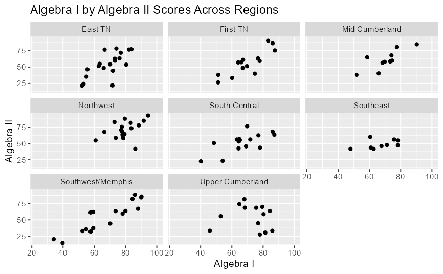

```r
ggplot(districts, aes(x=alg_1, y=alg_2)) +
  geom_point() +
  facet_wrap(~region) +
  labs(x = "Algebra I",
       y = "Algebra II",
       title = "Algebra I by Algebra II Scores Across Regions")
ggsave(file="../images/regionFacet_wrap.png", width=6, height=4)
```

4 districts

```r
  districts |>
  filter(is.na(enrollment)) |>
  nrow()
```

```
[1] 4
```

9. A lot of rows are missing additional values. Which district has the largest number of missing values (across all variables)? Hint: you might want to look at rowwise and c_across to answer this question.

West Tenn School for Deaf

```r
districts |>
  rowwise() |>
  mutate(na_count = sum(is.na(c_across(where(is.numeric))))) |>
  arrange(desc(na_count)) |>
  head(2)
```

| system | system_name | alg_1 | alg_2 | bio | chem | ela | eng_1 | eng_2 | eng_3 | math | science | enrollment | black | hispanic | native | el | swd | ed | expenditures | act_composite | chronic_abs | suspended | expelled | grad | dropout | region | na_count |
| --- | --- | --- | --- | --- | --- | --- | --- | --- | --- | --- | --- | --- | --- | --- | --- | --- | --- | --- | --- | --- | --- | --- | --- | --- | --- | --- | --- |
| 960 | West Tenn School for Deaf | NA | NA | NA | NA | NA | NA | NA | NA | NA | NA | NA | 48.7 | 7.7 | 0.0 | 0 | 97.4 | 76.9 | NA | NA | 23.1 | 0.0 | 0 | NA | NA | Southwest/Memphis | 15 |
| 11 | Clinton City | NA | NA | NA | NA | 58.3 | NA | NA | NA | 68.9 | 69.6 | 894 | 5.7 | 2.8 | 0.3 | 1 | 18.1 | 63.4 | 9537.5 | NA | 8.8 | 1.2 | 0 | NA | NA | East TN | 10 |

10. What is the mean graduation rate across all districts? What might be wrong with using just the regular mean to assess average graduation rates?

Using just the regular mean doesn’t account for other variables that can cause that number to be skewed in favor of schools with less students where the grad rate can be higher simply because of less students failing out.

```r
districts |>
  summarize(mean(grad, na.rm=TRUE))
```

| mean(grad, na.rm = TRUE) |
| --- |
| 90.06562 |

11. Redo the previous question but use a weighted average (`weighted.mean`) graduation across all districts, weighing by enrollment. How much does this change your answer? Can you explain using the data the reason for the big change from using the mean?

This changes the mean by 3. The data has a variation of enrollment sizes that, when accounted for, allows for the mean to be weighted and balances out the graduation rate.

```r
districts |>
 drop_na(c(grad, enrollment)) |>
  summarize(weighted.mean(grad, enrollment))
```

| weighted.mean(grad, enrollment) |
| --- |
| 87.33285 |

12. Find the unweighted and weighted average graduation rate by region.

```r
districts |>
  drop_na(grad, enrollment) |>
  group_by(region) |>
  summarize(mean = mean(grad), `weighted mean` = weighted.mean(grad, enrollment))
```

| region | mean | weighted mean |
| --- | --- | --- |
| East TN | 91.48947 | 89.87089 |
| First TN | 92.57333 | 91.91454 |
| Mid Cumberland | 91.51667 | 88.53965 |
| Northwest | 91.31579 | 91.57705 |
| South Central | 91.01333 | 90.47392 |
| Southeast | 89.09091 | 85.95494 |
| Southwest/Memphis | 87.10556 | 79.45971 |
| Upper Cumberland | 92.81250 | 92.24062 |

**Continued Exploration and Practice**

13. Read in the school-level testing data for 2014, available [here](https://www.tn.gov/content/dam/tn/education/data/data_2014_state_base.xlsx). You might find the readxl library useful for this task. If you use this library, be sure to look at the `na`argument for the `read_excel` function.

```r
library(readxl)

school_test_df <- read_excel('../data/data_2014_school_base.xlsx', na='')

print(school_test_df)
```

| year | system | system_name | school | school_name | subject | grade | subgroup | valid_tests | n_below_bsc | n_bsc | n_prof | n_adv | pct_below_bsc | pct_bsc | pct_prof | pct_adv | pct_bsc_and_below | pct_prof_adv |
| --- | --- | --- | --- | --- | --- | --- | --- | --- | --- | --- | --- | --- | --- | --- | --- | --- | --- | --- |
| 2014 | 10 | Anderson County | 2 | Anderson County High School | Algebra I | All Grades | All Students | 225 | 15 | 39 | 79 | 92 | 6.7 | 17.3 | 35.1 | 40.9 | 24 | 76 |
| 2014 | 10 | Anderson County | 2 | Anderson County High School | Algebra I | All Grades | White | 222 | 13 | 39 | 79 | 91 | 5.8 | 17.600000000000001 | 35.6 | 41 | 23.4 | 76.599999999999994 |
| 2014 | 10 | Anderson County | 2 | Anderson County High School | Algebra I | All Grades | Black | 1 | * | * | * | * | * | * | * | * | * | * |
| 2014 | 10 | Anderson County | 2 | Anderson County High School | Algebra I | All Grades | Asian | 1 | * | * | * | * | * | * | * | * | * | * |
| 2014 | 10 | Anderson County | 2 | Anderson County High School | Algebra I | All Grades | Native American | 1 | * | * | * | * | * | * | * | * | * | * |
| 2014 | 10 | Anderson County | 2 | Anderson County High School | Algebra I | All Grades | Economically Disadvantaged | 116 | 12 | 26 | 43 | 35 | 10.3 | 22.4 | 37.1 | 30.2 | 32.700000000000003 | 67.3 |
| 2014 | 10 | Anderson County | 2 | Anderson County High School | Algebra I | All Grades | Students with Disabilities | 35 | 9 | 12 | 9 | 5 | 25.7 | 34.299999999999997 | 25.7 | 14.3 | 60 | 40 |
| 2014 | 10 | Anderson County | 2 | Anderson County High School | Algebra I | All Grades | Black/Hispanic/Native American | 2 | * | * | * | * | * | * | * | * | * | * |
| 2014 | 10 | Anderson County | 2 | Anderson County High School | Algebra I | All Grades | Non-Economically Disadvantaged | 109 | 3 | 13 | 36 | 57 | 2.8 | 11.9 | 33 | 52.3 | 14.7 | 85.3 |
| 2014 | 10 | Anderson County | 2 | Anderson County High School | Algebra I | All Grades | Non-Students with Disabilities | 190 | 6 | 27 | 70 | 87 | 3.2 | 14.2 | 36.799999999999997 | 45.8 | 17.399999999999999 | 82.6 |

[output cut: 990 more lines]

To answer the following questions, use “All Students” for the subgroup.

```r
all_students <- school_test_df |>
  filter(subgroup == 'All Students') |>
  mutate_at(vars(n_below_bsc:pct_prof_adv), as.numeric)
```

14. How many schools have at least 20 percent of students below bsc for Algebra I? Which districts do these schools belong to?

```r
alg_sub_20 <- all_students |>
  filter(subject == 'Algebra I'
         & pct_below_bsc >= 20)

alg_sub_20 |>
  count()
```

| n |
| --- |
| 239 |

```r
alg_sub_20 |>
  distinct(system_name)
```

| system_name |
| --- |
| Anderson County |
| Oak Ridge |
| Bedford County |
| Bledsoe County |
| Blount County |
| Maryville |
| Bradley County |
| Campbell County |
| Hollow Rock-Bruceton |
| Carter County |

[output cut: 64 more lines]

15. How many schools have at least 20 percent of students below bsc for *both* Algebra I and English I?

```r
all_students |>
  filter(subject == c('Algebra I', 'English I')
         & pct_below_bsc >= 20) |>
  distinct(school_name) |>
  count()
```

| n |
| --- |
| 119 |

16. Which grade has the highest pct_adv for Algebra I? Plot the average pct_adv per grade level as a bar chart. Make sure that the bars are ordered by grade level.

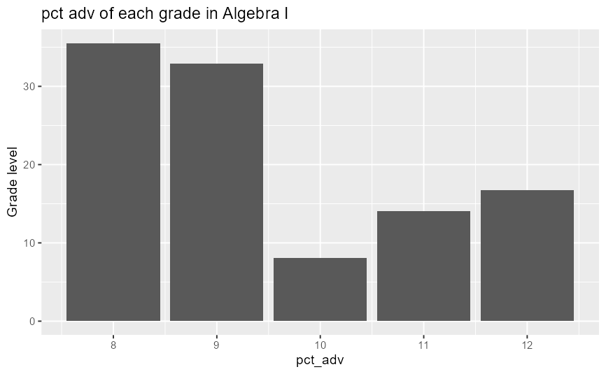

```r
grades <- all_students |>
  group_by(grade) |>
  filter(subject == 'Algebra I'
         & grade != 'Missing Grade'
         & grade != 'All Grades') |>
  mutate(grade = as.numeric(grade))


grades |>
  group_by(grade) |>
  summarize(pct_adv = mean(pct_adv, na.rm=TRUE)) |>
  ggplot(aes(x=grade, y=pct_adv)) +
  geom_col() +
  labs(x = "pct_adv",
       y = "Grade level",
       title = "pct adv of each grade in Algebra I")
ggsave(file="../images/pct_advByGrade.png", width=6, height=4)
```

17. Find the correlation between pct_adv for Algebra I and pct_adv for Algebra II by school. Create a scatterplot showing Algebra II scores vs. Algebra I scores by school.

```r
alg_III <- all_students |>
  drop_na(pct_adv) |>
  filter((subject == 'Algebra I' | subject == 'Algebra II') & grade == 'All Grades') |>
  select(c(system_name, school_name, subject, pct_adv)) |>
  pivot_wider(names_from = subject, values_from = pct_adv)
```

```r
alg_III |>
  select(`Algebra I`, `Algebra II`) |>
  cor(use = "pairwise.complete.obs")
```

```
           Algebra I Algebra II
Algebra I  1.0000000  0.6026042
Algebra II 0.6026042  1.0000000
```

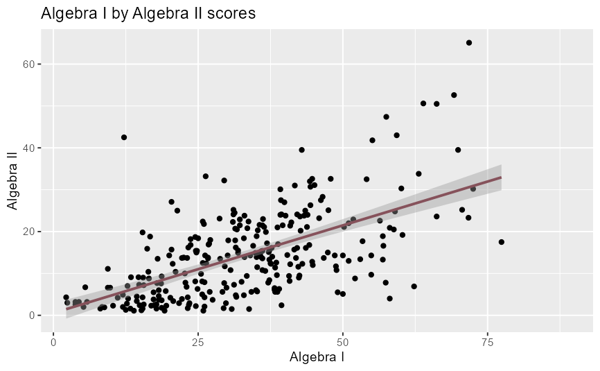

```r
ggplot(alg_III, aes(x=`Algebra I`, y=`Algebra II`)) +
  geom_point() +
  geom_smooth(method = 'lm', color='#86525B') +
  labs(x = "Algebra I", y = "Algebra II", title = "Algebra I by Algebra II scores")
ggsave(file="../images/ag1ByAlg2.png", width=6, height=4)
```

18. Find all schools in Rutherford County that have “High School” in their name. For these schools, create a chart (your choice) showing the differences in pct_below_bsc, pct_bsc, pct_prof, and pct_adv for Algebra I when looking across all subgroups and grades.

```r
all_schools <-  all_students |>
  filter(system_name == 'Rutherford County'
         & grepl('High School', school_name)
         & subject == 'Algebra I'
         & grade == 'All Grades') |>
  group_by(school_name, grade) |>
  select(school_name,
         grade,
         pct_below_bsc,
         pct_bsc,
         pct_prof,
         pct_adv)

dfm <- all_schools |>
  pivot_longer(c(pct_below_bsc,
                 pct_bsc,
                 pct_prof,
                 pct_adv))

labels_school <- c('Blackman',
                   'Holloway',
                   'LaVergne',
                   'Oakland',
                   'Riverdale',
                   'Smyrna',
                   'Siegel',
                   'Stewart\'s Creek' )

rutherford_plot <- ggplot(dfm, aes(x=school_name, y=value, fill=name)) +
  geom_col(position = "dodge", stat = "identity") +
  scale_x_discrete(labels=labels_school, colors()) +
  scale_fill_manual(values = c("#6C2CDB",
                               "#86525B",
                               "#5C5740",
                               "#40485C")) +
  theme(panel.background = element_blank()) +
  labs(x = "Schools", y = "Percent", title = "The percent values of each high school in Rutherford County")
ggsave("../images/Rutherford_Bar.png", rutherford_plot)
```

19. Create a function which allows you to select a system_name and which creates a plot to show the differences in pct_below_bsc, pct_bsc, pct_prof, and pct_adv for Algebra I when looking across all subgroups and grades for all schools with “High School” in their names within that system.

```r
county_func <- function(df, county){
  df <- df |>
  filter(system_name == county,
         grepl('High School', school_name)
         & subject == 'Algebra I'
         & grade == 'All Grades') |>
  group_by(system_name, grade) |>
  select(system_name,
         school_name,
         subgroup,
         grade,
         pct_below_bsc:pct_adv)
    df$school_name <- substr(df$school_name, 1, nchar(df$school_name)-11)

  dff <- df |>
  pivot_longer(c(pct_below_bsc,
                 pct_bsc,
                 pct_prof,
                 pct_adv))

  plots <- ggplot(dff, aes(x=school_name, y=value, fill=name)) +
  geom_col(position = "dodge", stat = "identity") +
    scale_fill_manual(values = c("#6C2CDB",
                               "#86525B",
                               "#5C5740",
                               "#40485C")) +
    facet_wrap(~subgroup,
               scales = "free_y", nrow = 3) +
    theme(panel.background = element_blank(),
          axis.text.x = element_text(angle = 45, hjust = 1)) +
  labs(x = "Schools",
       y = "Percent",
       title = glue("The percent values of each high school in {county}"))
  ggsave(file=glue("../images/{county} Bar.png"), width=6, height=4, plots)
  print(plots)
  }
```

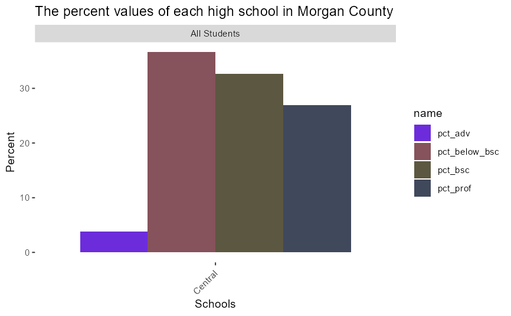

```r
county_func(df = all_students, county="Morgan County")
```